# How to use the `coxed` function

# 4 Using the GAM method within the `coxed()` function

We can use the GAM method to for all of the same uses for which we used the NPSF method above, except for estimating the baseline functions. We can however view and plot the output from the GAM model that maps predicted ranks to duration. While the `bootstrap=TRUE` argument works when `method="gam"`, these functions take somewhat longer to run. We therefore run the following examples without bootstrapping.

As before, to see predicted durations from the Cox model, place the Cox model output as the first argument of `coxed()`. The predicted durations for each individual observation are stored in the `exp.dur` attribute,

```r
ed2 <- coxed(mv.cox, method="gam")
head(ed2$exp.dur)
```

```
##     exp.dur
## 1 48.978295
## 2 42.036276
## 3 55.440293
## 4 15.734577
## 5  1.530695
## 6 64.449942
```

and `summary()` reports either the mean or median expected duration:

```r
summary(ed2, stat="mean")
```

```
##   mean
## 28.034
```

```r
summary(ed2, stat="median")
```

```
## median
## 21.208
```

## 4.1 Out of sample prediction

The GAM method can also forecast durations for new data along with standard errors and confidence intervals. Here we use the `coxed()` function with `method="gam"` and place the `new.coalitions` we created above into the `newdata` argument:

```r
forecast <- coxed(mv.cox, newdata=new.coalitions, method="gam")
forecast$exp.dur
```

```
##     exp.dur
## 1  6.614393
## 2  3.194893
## 3 18.159002
```

## 4.2 Marginal changes in expected duration

Here we again calculate the two marginal effects to better understand the substantive meaning of the Cox model. This time we employ the GAM method instead of the NPSF method. The GAM method may provide a warning that some observations have linear predictors that are greater than or less than all of the observed cases in the estimation sample. Some observations falling outside the range of the original linear predictors is to be expected when applying new data, but if it happens with too many of the new observations NPSF may be a better option for estimating these quantities.

```r
me <- coxed(mv.cox, method="gam",
            newdata = dplyr::mutate(martinvanberg, rgovm=0),
            newdata2 = dplyr::mutate(martinvanberg, rgovm=1.24))
```

```
## Warning in rank.predict(x = exp.xb2, v = exp.xb, ties.method =
## ties.method, : New data contain 1 observations with linear predictors
## greater than all linear predictors in the estimation sample. These
## observations will all have the same predicted duration

## Warning in rank.predict(x = exp.xb2, v = exp.xb, ties.method =
## ties.method, : New data contain 1 observations with linear predictors
## greater than all linear predictors in the estimation sample. These
## observations will all have the same predicted duration
```

```r
summary(me, stat="mean")
```

```
##   newdata2    newdata difference
##     25.316     28.927      3.611
```

```r
summary(me, stat="median")
```

```
##   newdata2    newdata difference
##     19.692     22.392      3.006
```

```r
me <- coxed(mv.cox, method="gam",
            newdata = dplyr::mutate(martinvanberg, pgovno=1),
            newdata2 = dplyr::mutate(martinvanberg, pgovno=6))
summary(me, stat="mean")
```

```
##   newdata2    newdata difference
##     47.505      6.083    -41.422
```

```r
summary(me, stat="median")
```

```
##   newdata2    newdata difference
##     36.807      0.592    -31.934
```

## 4.3 Plotting the GAM fit

The data used by `coxed()` to map rankings to durations are stored in the `gam.data` attribute, and the output from the GAM is stored in `gam.model`:

```r
summary(ed2$gam.data)
```

```
##        y              failed     rank.xb          rank.y
##  Min.   :  1.00   Min.   :1   Min.   :  1.0   Min.   :  1.0
##  1st Qu.:  6.00   1st Qu.:1   1st Qu.: 51.5   1st Qu.: 51.5
##  Median : 19.00   Median :1   Median :102.0   Median :102.0
##  Mean   : 28.03   Mean   :1   Mean   :102.0   Mean   :102.0
##  3rd Qu.: 37.50   3rd Qu.:1   3rd Qu.:152.5   3rd Qu.:152.5
##  Max.   :205.00   Max.   :1   Max.   :203.0   Max.   :203.0
##     gam_fit           gam_fit_se     gam_fit_95lb      gam_fit_95ub
##  Min.   :  0.3262   Min.   :2.645   Min.   :-10.183   Min.   :  7.497
##  1st Qu.:  7.3341   1st Qu.:2.701   1st Qu.:  1.994   1st Qu.: 12.674
##  Median : 21.2081   Median :2.754   Median : 16.024   Median : 26.392
##  Mean   : 28.0345   Mean   :2.919   Mean   : 22.313   Mean   : 33.756
##  3rd Qu.: 38.2803   3rd Qu.:2.810   3rd Qu.: 32.941   3rd Qu.: 43.620
##  Max.   :105.3490   Max.   :5.362   Max.   : 94.840   Max.   :115.858
```

```r
summary(ed2$gam.model)
```

```
##
## Family: gaussian
## Link function: identity
##
## Formula:
## y ~ s(rank.xb, bs = "cr", k = k)
##
## Parametric coefficients:
##             Estimate Std. Error t value Pr(>|t|)
## (Intercept)   28.034      1.198   23.39   <2e-16 ***
## ---
## Signif. codes:  0 '***' 0.001 '**' 0.01 '*' 0.05 '.' 0.1 ' ' 1
##
## Approximate significance of smooth terms:
##              edf Ref.df     F p-value
## s(rank.xb) 5.122  6.214 77.47  <2e-16 ***
## ---
## Signif. codes:  0 '***' 0.001 '**' 0.01 '*' 0.05 '.' 0.1 ' ' 1
##
## R-sq.(adj) =  0.704   Deviance explained = 71.2%
## GCV = 300.59  Scale est. = 291.53    n = 203
```

The `gam.data` can be used to visualize the fit of the GAM:

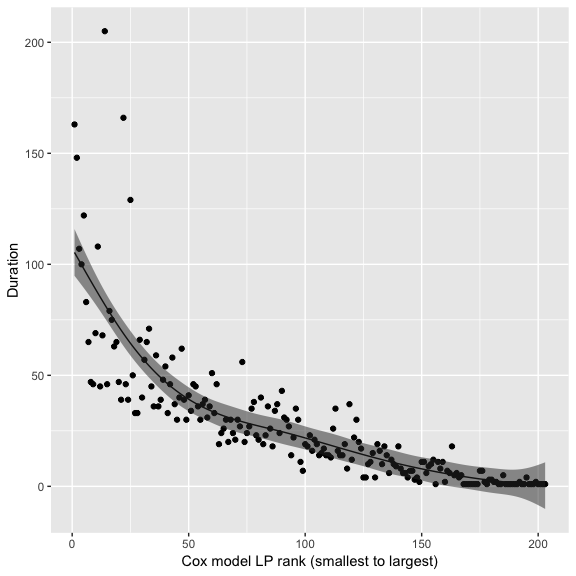

```r
ggplot(ed2$gam.data, aes(x=rank.xb, y=y)) +
     geom_point() +
     geom_line(aes(x=rank.xb, y=gam_fit)) +
     geom_ribbon(aes(ymin=gam_fit_95lb, ymax=gam_fit_95ub), alpha=.5) +
     xlab("Cox model LP rank (smallest to largest)") +
     ylab("Duration")
```

# 5 Comparing the predicted durations to the observed durations and to each other

Given that `coxed()` contains two alternative methods for generating expected durations, it is possible to compare the estimates. Both correlate positively the observed durations, and the GAM and NPSF durations correlate even more strongly with each other.

```r
tester <- data.frame(y=martinvanberg$formdur, npsf=ed1$exp.dur$exp.dur, gam=ed2$exp.dur$exp.dur)
cor(tester)
```

```
##              y      npsf       gam
## y    1.0000000 0.8240072 0.8436075
## npsf 0.8240072 1.0000000 0.9119669
## gam  0.8436075 0.9119669 1.0000000
```

Scatterplots visualize these correlations:

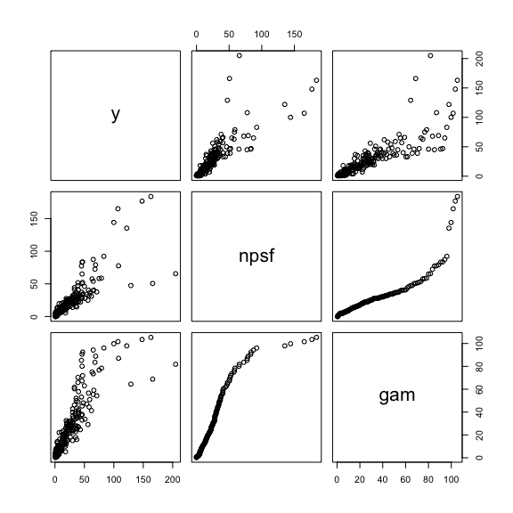

```r
pairs(tester)
```

# 6 Expected durations and marginal changes in duration with time-varying covariates

To illustrate the use of `coxed()` with time-varying covariates, we use another working example. To set up this example, we quote from the online appendix to Kropko and Harden (2018):

> Box-Steffensmeier (1996) examines whether U.S. House incumbents’ ability to raise campaign funds can effectively deter quality challengers from entering the race. The theoretical expectation is that as incumbents raise more money, challengers further delay their decision to run for the incumbent’s seat. She employs data on 397 House races in the 1989–1990 election cycle to test this hypothesis. The dependent variable in this analysis is the number of weeks after January 1, 1989 when a challenger entered the race. Races in which no challenger entered are coded as the number of weeks after January 1 when the state’s primary filing deadline occurred, and are treated as censored. The key independent variable is the incumbent’s War chest, or the amount of money in millions of dollars that the incumbent has in reserve at a given time. Importantly, this measure updates over the course of five Federal Election Commission (FEC) reporting periods, so it is a time-varying covariate (TVC). The theory predicts a negative coefficient on this variable, which would indicate that as the incumbent raises more money, the hazard of challenger entry declines (and the time until entry increases).

Box-Steffensmeier’s model is replicated below. Note that the `Surv()` function which sets up the dependent variable has two time arguments, representing the start and end of discrete intervals, which allows a covariate to take on different values across different intervals for the same observation.

```r
bs.surv <- Surv(time = boxsteffensmeier$start, time2 = boxsteffensmeier$te, event = boxsteffensmeier$cut_hi)
bs.cox <- coxph(bs.surv ~ ec + dem + south + iv, data = boxsteffensmeier, method = "breslow")
summary(bs.cox)
```

```
## Call:
## coxph(formula = bs.surv ~ ec + dem + south + iv, data = boxsteffensmeier,
##     method = "breslow")
##
##   n= 1376, number of events= 40
##
##             coef  exp(coef)   se(coef)      z Pr(>|z|)
## ec    -3.0305806  0.0482876  1.3961518 -2.171    0.030 *
## dem    0.2124840  1.2367464  0.3266545  0.650    0.515
## south -0.4266388  0.6526992  0.4240698 -1.006    0.314
## iv    -7.2790246  0.0006899  1.6996244 -4.283 1.85e-05 ***
## ---
## Signif. codes:  0 '***' 0.001 '**' 0.01 '*' 0.05 '.' 0.1 ' ' 1
##
##       exp(coef) exp(-coef) lower .95 upper .95
## ec    0.0482876    20.7093 3.129e-03    0.7451
## dem   1.2367464     0.8086 6.520e-01    2.3460
## south 0.6526992     1.5321 2.843e-01    1.4986
## iv    0.0006899  1449.5734 2.466e-05    0.0193
##
## Concordance= 0.773  (se = 0.052 )
## Rsquare= 0.025   (max possible= 0.259 )
## Likelihood ratio test= 35.04  on 4 df,   p=5e-07
## Wald test            = 25.52  on 4 df,   p=4e-05
## Score (logrank) test = 26.9  on 4 df,   p=2e-05
```

The `coxed()` function automatically detects whether time-varying covariates are used in the model and it takes steps to account for this structure in predicting expected durations and in estimating marginal effects. The only additional step that the user needs to take is to specify the ID variable in the `id` argument, so that the function knows which intervals refer to which observations.

```r
ed1 <- coxed(bs.cox, method="npsf", id=boxsteffensmeier$caseid)
summary(ed1, stat="mean")
```

```
##  mean
## 82.08
```

Here we look directly at the effect of the war chest on the length of time until a high quality challenger enters the race. We compare the 25th and 75th percentiles in war chest variable:

```r
me <- coxed(bs.cox, method="npsf",
            newdata = mutate(boxsteffensmeier, ec=quantile(ec, .25)),
            newdata2 = mutate(boxsteffensmeier, ec=quantile(ec, .75)),
            id=boxsteffensmeier$caseid)
summary(me, stat="mean")
```

```
##   newdata2    newdata difference
##     81.431     82.925      1.494
```

```r
summary(me, stat="median")
```

```
##   newdata2    newdata difference
##     81.945     83.269      1.325
```

# 7 References

- Box-Steffensmeier, J. M. (1996) “A Dynamic Analysis of The Role of War Chests in Campaign Strategy.” *American Journal of Political Science* **40**: 352-371.
- Kropko, J. and Harden, J. J. (2018) “Beyond the Hazard Ratio: Generating Expected Durations from the Cox Proportional Hazards Model.” *British Journal of Political Science* https://doi.org/10.1017/S000712341700045X
- Martin, L. W and Vanberg, G. (2003) “Wasting Time? The Impact of Ideology and Size on Delay in Coalition Formation.” *British Journal of Political Science* **33** 323-344 https://doi.org/10.1017/S0007123403000140